# Caso 6. Comparación modelos de regresión. Datos Precios autos. Programación R

Luis Alberto Jimenez Soto

2022-10-17

# 1 Objetivo

Comparar modelos de supervisados a través de la aplicación de algoritmos de predicción de precios de automóviles determinando el estadístico del error cuadrático medio (*rmse*).

# 2 Descripción

- Se cargan los datos previamente preparados de la dirección https://raw.githubusercontent.com/rpizarrog/Analisis-Inteligente-de-datos/main/datos/CarPrice_Assignment_Numericas_Preparado.csv
- Se crean datos de entrenamiento al 80%
- Se crean datos de validación al 20%
- Se crea el modelo regresión múltiple con datos de entrenamiento
  - Con este modelo se responde a preguntas tales como:
    - ¿cuáles son variables que están por encima del 90% de confianza como predictores?,
    - ¿Cuál es el valor de *R Square Adjusted* o que tanto representan las variables dependientes al precio del vehículo?
  - Se generan predicciones con datos de validación
  - Se determina el estadístico *RMSE* para efectos de comparación
- Se crea el modelo árboles de regresión con los datos de entrenamiento
  - Se identifica la importancia de las variables sobre el precio
  - Se visualiza el árbol de regresión y sus reglas de asociación
- Se hacen predicciones con datos de validación
- Se determinar el estadístico *RMSE* para efectos de comparación
- Se construye el modelo bosques aleatorios con datos de entrenamiento y con 20 árboles simulados
  - Se identifica la importancia de las variables sobre el precio
  - Se generan predicciones con datos de validación
  - Se determina el estadístico RMSE para efectos de comparación
- Al final del caso, se describe una interpretación personal

# 3 Desarrollo

## 3.1 Cargar librerías

```r
# Librerías
library(readr)
library(PerformanceAnalytics) # Para correlaciones gráficas
library(dplyr)
library(knitr) # Para datos tabulares
library(kableExtra) # Para datos tabulares amigables
library(ggplot2) # Para visualizar
library(plotly) # Para visualizar
library(caret)  # Para particionar
library(Metrics) # Para determinar rmse
library(rpart) # Para árbol
library(rpart.plot) # Para árbol
library(randomForest) # Para random forest
library(caret) # Para hacer divisiones o particiones
library(reshape)    # Para renombrar columnas
```

## 3.2 Cargar datos

```r
datos <- read.csv("https://raw.githubusercontent.com/rpizarrog/Analisis-Inteligente-de-datos/main/datos/CarPrice_Assignment_Numericas_Preparado.csv")
```

### 3.2.1 Exploración de datos

```r
str(datos)
```

```
## 'data.frame':    205 obs. of  16 variables:
##  $ X               : int  1 2 3 4 5 6 7 8 9 10 ...
##  $ symboling       : int  3 3 1 2 2 2 1 1 1 0 ...
##  $ wheelbase       : num  88.6 88.6 94.5 99.8 99.4 ...
##  $ carlength       : num  169 169 171 177 177 ...
##  $ carwidth        : num  64.1 64.1 65.5 66.2 66.4 66.3 71.4 71.4 71.4 67.9 ...
##  $ carheight       : num  48.8 48.8 52.4 54.3 54.3 53.1 55.7 55.7 55.9 52 ...
##  $ curbweight      : int  2548 2548 2823 2337 2824 2507 2844 2954 3086 3053 ...
##  $ enginesize      : int  130 130 152 109 136 136 136 136 131 131 ...
##  $ boreratio       : num  3.47 3.47 2.68 3.19 3.19 3.19 3.19 3.19 3.13 3.13 ...
##  $ stroke          : num  2.68 2.68 3.47 3.4 3.4 3.4 3.4 3.4 3.4 3.4 ...
##  $ compressionratio: num  9 9 9 10 8 8.5 8.5 8.5 8.3 7 ...
##  $ horsepower      : int  111 111 154 102 115 110 110 110 140 160 ...
##  $ peakrpm         : int  5000 5000 5000 5500 5500 5500 5500 5500 5500 5500 ...
##  $ citympg         : int  21 21 19 24 18 19 19 19 17 16 ...
##  $ highwaympg      : int  27 27 26 30 22 25 25 25 20 22 ...
##  $ price           : num  13495 16500 16500 13950 17450 ...
```

### 3.2.2 Diccionario de datos

| Col | Nombre | Descripción |
| --- | --- | --- |
| 1 | *Symboling* | *Its assigned insurance risk rating, A value of +3 indicates that the auto is risky, -3 that it is probably pretty safe.(Categorical)* |
| 2 | *wheelbase* | *Weelbase of car (Numeric). Distancia de ejes en pulgadas.* |
| 3 | *carlength* | *Length of car (Numeric). Longitud* |
| 4 | *carwidth* | *Width of car (Numeric). Amplitud* |
| 5 | *carheight* | *height of car (Numeric). Altura* |
| 6 | *curbweight* | *The weight of a car without occupants or baggage. (Numeric). Peso del auto* |
| *7* | *enginesize* | *Size of car (Numeric). Tamaño del carro en …* |
| 8 | *boreratio* | *Boreratio of car (Numeric). Eficiencia de motor* |
| *9* | *stroke* | *Stroke or volume inside the engine (Numeric). Pistones, tiempos, combustión* |
| *1*0 | *compressionratio* | *compression ratio of car (Numeric). Comprensión o medición de presión en motor* |
| 11 | *horsepower* | *Horsepower (Numeric). Poder del carro* |
| 12 | *peakrpm* | *car peak rpm (Numeric). Picos de revoluciones por minuto* |
| 13 | *citympg* | *Mileage in city (Numeric). Consumo de gasolina* |
| 14 | *highwaympg* | *Mileage on highway (Numeric). Consumo de gasolina* |
| 16 | *price* *(Dependent variable)* | *Price of car (Numeric). Precio del carro en dólares* |

~**Fuente**: https://archive.ics.uci.edu/ml/datasets/Automobile~

### 3.2.3 Primeros (10) registros

```r
kable(head(datos, 10), caption = "Datos de precios de carros") %>%
  kable_styling(full_width = F, bootstrap_options = c("striped", "bordered", "condensed")) %>%
 kable_paper("hover")
```

Datos de precios de carros

| X | symboling | wheelbase | carlength | carwidth | carheight | curbweight | enginesize | boreratio | stroke | compressionratio | horsepower | peakrpm | citympg | highwaympg | price |
| --- | --- | --- | --- | --- | --- | --- | --- | --- | --- | --- | --- | --- | --- | --- | --- |
| 1 | 3 | 88.6 | 168.8 | 64.1 | 48.8 | 2548 | 130 | 3.47 | 2.68 | 9.0 | 111 | 5000 | 21 | 27 | 13495.00 |
| 2 | 3 | 88.6 | 168.8 | 64.1 | 48.8 | 2548 | 130 | 3.47 | 2.68 | 9.0 | 111 | 5000 | 21 | 27 | 16500.00 |
| 3 | 1 | 94.5 | 171.2 | 65.5 | 52.4 | 2823 | 152 | 2.68 | 3.47 | 9.0 | 154 | 5000 | 19 | 26 | 16500.00 |
| 4 | 2 | 99.8 | 176.6 | 66.2 | 54.3 | 2337 | 109 | 3.19 | 3.40 | 10.0 | 102 | 5500 | 24 | 30 | 13950.00 |
| 5 | 2 | 99.4 | 176.6 | 66.4 | 54.3 | 2824 | 136 | 3.19 | 3.40 | 8.0 | 115 | 5500 | 18 | 22 | 17450.00 |
| 6 | 2 | 99.8 | 177.3 | 66.3 | 53.1 | 2507 | 136 | 3.19 | 3.40 | 8.5 | 110 | 5500 | 19 | 25 | 15250.00 |
| 7 | 1 | 105.8 | 192.7 | 71.4 | 55.7 | 2844 | 136 | 3.19 | 3.40 | 8.5 | 110 | 5500 | 19 | 25 | 17710.00 |
| 8 | 1 | 105.8 | 192.7 | 71.4 | 55.7 | 2954 | 136 | 3.19 | 3.40 | 8.5 | 110 | 5500 | 19 | 25 | 18920.00 |
| 9 | 1 | 105.8 | 192.7 | 71.4 | 55.9 | 3086 | 131 | 3.13 | 3.40 | 8.3 | 140 | 5500 | 17 | 20 | 23875.00 |
| 10 | 0 | 99.5 | 178.2 | 67.9 | 52.0 | 3053 | 131 | 3.13 | 3.40 | 7.0 | 160 | 5500 | 16 | 22 | 17859.17 |

### 3.2.4 Datos de entrenamiento y validación

Datos de entrenamiento al 80% de los datos y 20% los datos de validación.

```r
n <- nrow(datos)
set.seed(1271) # Semilla
entrena <- createDataPartition(y = datos$price, p = 0.80, list = FALSE, times = 1)
# Datos entrenamiento
datos.entrenamiento <- datos[entrena, ]  # [renglones, columna]
# Datos validación
datos.validacion <- datos[-entrena, ]
```

#### 3.2.4.1 Datos de entrenamiento

```r
kable(head(datos.entrenamiento, 10), caption = "Datos de Entrenamient. Precios de carros") %>%
  kable_styling(full_width = F, bootstrap_options = c("striped", "bordered", "condensed")) %>%
 kable_paper("hover")
```

Datos de Entrenamient. Precios de carros

|  | X | symboling | wheelbase | carlength | carwidth | carheight | curbweight | enginesize | boreratio | stroke | compressionratio | horsepower | peakrpm | citympg | highwaympg | price |
| --- | --- | --- | --- | --- | --- | --- | --- | --- | --- | --- | --- | --- | --- | --- | --- | --- |
| 1 | 1 | 3 | 88.6 | 168.8 | 64.1 | 48.8 | 2548 | 130 | 3.47 | 2.68 | 9.0 | 111 | 5000 | 21 | 27 | 13495 |
| 2 | 2 | 3 | 88.6 | 168.8 | 64.1 | 48.8 | 2548 | 130 | 3.47 | 2.68 | 9.0 | 111 | 5000 | 21 | 27 | 16500 |
| 3 | 3 | 1 | 94.5 | 171.2 | 65.5 | 52.4 | 2823 | 152 | 2.68 | 3.47 | 9.0 | 154 | 5000 | 19 | 26 | 16500 |
| 4 | 4 | 2 | 99.8 | 176.6 | 66.2 | 54.3 | 2337 | 109 | 3.19 | 3.40 | 10.0 | 102 | 5500 | 24 | 30 | 13950 |
| 5 | 5 | 2 | 99.4 | 176.6 | 66.4 | 54.3 | 2824 | 136 | 3.19 | 3.40 | 8.0 | 115 | 5500 | 18 | 22 | 17450 |
| 6 | 6 | 2 | 99.8 | 177.3 | 66.3 | 53.1 | 2507 | 136 | 3.19 | 3.40 | 8.5 | 110 | 5500 | 19 | 25 | 15250 |
| 7 | 7 | 1 | 105.8 | 192.7 | 71.4 | 55.7 | 2844 | 136 | 3.19 | 3.40 | 8.5 | 110 | 5500 | 19 | 25 | 17710 |
| 8 | 8 | 1 | 105.8 | 192.7 | 71.4 | 55.7 | 2954 | 136 | 3.19 | 3.40 | 8.5 | 110 | 5500 | 19 | 25 | 18920 |
| 11 | 11 | 2 | 101.2 | 176.8 | 64.8 | 54.3 | 2395 | 108 | 3.50 | 2.80 | 8.8 | 101 | 5800 | 23 | 29 | 16430 |
| 12 | 12 | 0 | 101.2 | 176.8 | 64.8 | 54.3 | 2395 | 108 | 3.50 | 2.80 | 8.8 | 101 | 5800 | 23 | 29 | 16925 |

#### 3.2.4.2 Datos de validación

```r
kable(head(datos.validacion, 10), caption = "Datos de Validación. Precios de carros") %>%
  kable_styling(full_width = F, bootstrap_options = c("striped", "bordered", "condensed")) %>%
 kable_paper("hover")
```

Datos de Validación. Precios de carros

|  | X | symboling | wheelbase | carlength | carwidth | carheight | curbweight | enginesize | boreratio | stroke | compressionratio | horsepower | peakrpm | citympg | highwaympg | price |
| --- | --- | --- | --- | --- | --- | --- | --- | --- | --- | --- | --- | --- | --- | --- | --- | --- |
| 9 | 9 | 1 | 105.8 | 192.7 | 71.4 | 55.9 | 3086 | 131 | 3.13 | 3.400 | 8.3 | 140 | 5500 | 17 | 20 | 23875.00 |
| 10 | 10 | 0 | 99.5 | 178.2 | 67.9 | 52.0 | 3053 | 131 | 3.13 | 3.400 | 7.0 | 160 | 5500 | 16 | 22 | 17859.17 |
| 33 | 33 | 1 | 93.7 | 150.0 | 64.0 | 52.6 | 1837 | 79 | 2.91 | 3.070 | 10.1 | 60 | 5500 | 38 | 42 | 5399.00 |
| 44 | 44 | 0 | 94.3 | 170.7 | 61.8 | 53.5 | 2337 | 111 | 3.31 | 3.230 | 8.5 | 78 | 4800 | 24 | 29 | 6785.00 |
| 47 | 47 | 2 | 96.0 | 172.6 | 65.2 | 51.4 | 2734 | 119 | 3.43 | 3.230 | 9.2 | 90 | 5000 | 24 | 29 | 11048.00 |
| 56 | 56 | 3 | 95.3 | 169.0 | 65.7 | 49.6 | 2380 | 70 | 3.33 | 3.255 | 9.4 | 101 | 6000 | 17 | 23 | 10945.00 |
| 57 | 57 | 3 | 95.3 | 169.0 | 65.7 | 49.6 | 2380 | 70 | 3.33 | 3.255 | 9.4 | 101 | 6000 | 17 | 23 | 11845.00 |
| 72 | 72 | -1 | 115.6 | 202.6 | 71.7 | 56.5 | 3740 | 234 | 3.46 | 3.100 | 8.3 | 155 | 4750 | 16 | 18 | 34184.00 |
| 77 | 77 | 2 | 93.7 | 157.3 | 64.4 | 50.8 | 1918 | 92 | 2.97 | 3.230 | 9.4 | 68 | 5500 | 37 | 41 | 5389.00 |
| 84 | 84 | 3 | 95.9 | 173.2 | 66.3 | 50.2 | 2921 | 156 | 3.59 | 3.860 | 7.0 | 145 | 5000 | 19 | 24 | 14869.00 |

## 3.3 Modelos Supervisados

### 3.3.1 Modelo de regresión lineal múltiple. (RM)

Se construye el modelo de regresión lineal múltiple (rm)

```r
# Modelo de regresión lineal múltiple para observar variables de importancia
modelo_rm <- lm(formula = price ~ symboling +  wheelbase + carlength + carwidth + carheight + curbweight + enginesize + boreratio + stroke + compressionratio + horsepower + peakrpm + citympg + highwaympg ,
                data = datos.entrenamiento)
```

```r
summary(modelo_rm)
```

```
##
## Call:
## lm(formula = price ~ symboling + wheelbase + carlength + carwidth +
##     carheight + curbweight + enginesize + boreratio + stroke +
##     compressionratio + horsepower + peakrpm + citympg + highwaympg,
##     data = datos.entrenamiento)
##
## Residuals:
##      Min       1Q   Median       3Q      Max
## -11507.1  -1689.2   -187.6   1401.1  13627.9
##
## Coefficients:
##                    Estimate Std. Error t value Pr(>|t|)
## (Intercept)      -46322.258  18280.752  -2.534 0.012305 *
## symboling            64.364    280.958   0.229 0.819112
## wheelbase           135.009    120.780   1.118 0.265436
## carlength           -86.062     62.750  -1.372 0.172264
## carwidth            324.450    285.859   1.135 0.258185
## carheight           162.791    163.722   0.994 0.321674
## curbweight            1.837      2.311   0.795 0.427941
## enginesize          133.912     16.136   8.299 5.64e-14 ***
## boreratio           449.081   1419.698   0.316 0.752198
## stroke            -3428.857    889.463  -3.855 0.000171 ***
## compressionratio    292.481    100.613   2.907 0.004203 **
## horsepower           19.572     18.852   1.038 0.300836
## peakrpm               2.841      0.772   3.680 0.000324 ***
## citympg            -396.153    207.315  -1.911 0.057928 .
## highwaympg          310.853    187.381   1.659 0.099218 .
## ---
## Signif. codes:  0 '***' 0.001 '**' 0.01 '*' 0.05 '.' 0.1 ' ' 1
##
## Residual standard error: 3310 on 150 degrees of freedom
## Multiple R-squared:  0.8578, Adjusted R-squared:  0.8446
## F-statistic: 64.65 on 14 and 150 DF,  p-value: < 2.2e-16
```

- ¿cuáles son variables que están por encima del 90% de confianza como predictores?
  - enginesize
  - stroke
  - compressionratio
  - peakrpm
  - citympg
  - highwaympg
- El coeficiente de intersección tiene un nivel de confianza del 98%.

#### 3.3.1.1 Predicciones del modelo rm

```r
predicciones_rm <- predict(object = modelo_rm, newdata = datos.validacion)
predicciones_rm
```

```
##         9        10        33        44        47        56        57        72
## 16942.803 16473.778  5301.044  7204.223 11022.515  7851.656  7851.656 31588.516
##        77        84        87        89        97       100       104       107
##  5979.030 15252.727 10378.638 10405.155  6684.602 10903.360 22703.983 23008.175
##       108       116       122       132       138       140       142       147
## 14327.392 14428.427  6166.339 11091.658 16276.811  8985.576  9585.263  9661.038
##       148       149       155       156       160       161       167       171
## 12213.061 11235.252  6490.468  7996.805 10685.304  7017.584 11959.446 14219.038
##       173       178       188       192       196       201       203       204
## 14925.579  8406.054  8669.066 15473.126 17905.580 18628.974 24791.956 19036.351
```

#### 3.3.1.2 Tabla comparativa

```r
comparaciones <- data.frame(precio_real = datos.validacion$price,  precio_predicciones = predicciones_rm)
```

```r
kable(head(comparaciones, 10), caption = "Regresión Lineal Múltiple. Comparación precios reales VS predicción de precios. 10 primeras predicciones") %>%
  kable_styling(full_width = F, bootstrap_options = c("striped", "bordered", "condensed")) %>%
 kable_paper("hover")
```

Regresión Lineal Múltiple. Comparación precios reales VS predicción de precios. 10 primeras predicciones

|  | precio_real | precio_predicciones |
| --- | --- | --- |
| 9 | 23875.00 | 16942.803 |
| 10 | 17859.17 | 16473.778 |
| 33 | 5399.00 | 5301.044 |
| 44 | 6785.00 | 7204.223 |
| 47 | 11048.00 | 11022.515 |
| 56 | 10945.00 | 7851.656 |
| 57 | 11845.00 | 7851.656 |
| 72 | 34184.00 | 31588.516 |
| 77 | 5389.00 | 5979.030 |
| 84 | 14869.00 | 15252.727 |

#### 3.3.1.3 RMSE modelo de rm

```r
rmse_rm <- rmse(comparaciones$precio_real, comparaciones$precio_predicciones)
rmse_rm
```

```
## [1] 2915.551
```

### 3.3.2 Modelo de árbol de regresión (AR)

Se construye el modelo de árbol de regresión (ar)

```r
modelo_ar <- rpart(formula = price ~ symboling +  wheelbase + carlength + carwidth + carheight + curbweight + enginesize + boreratio + stroke + compressionratio + horsepower + peakrpm + citympg + highwaympg ,
                data = datos.entrenamiento )
modelo_ar
```

```
## n= 165
##
## node), split, n, deviance, yval
##       * denotes terminal node
##
##  1) root 165 11562880000 13522.800
##    2) enginesize< 182 148  2976024000 11138.720
##      4) curbweight< 2664 104   693947700  8805.567
##        8) curbweight< 2291 63    92941480  7319.714 *
##        9) curbweight>=2291 41   248195500 11088.710
##         18) highwaympg>=29.5 29    63171640  9991.931 *
##         19) highwaympg< 29.5 12    65834740 13739.250 *
##      5) curbweight>=2664 44   377800600 16653.450 *
##    3) enginesize>=182 17   422193000 34278.320 *
```

#### 3.3.2.2 Visualización de árbol de regresión

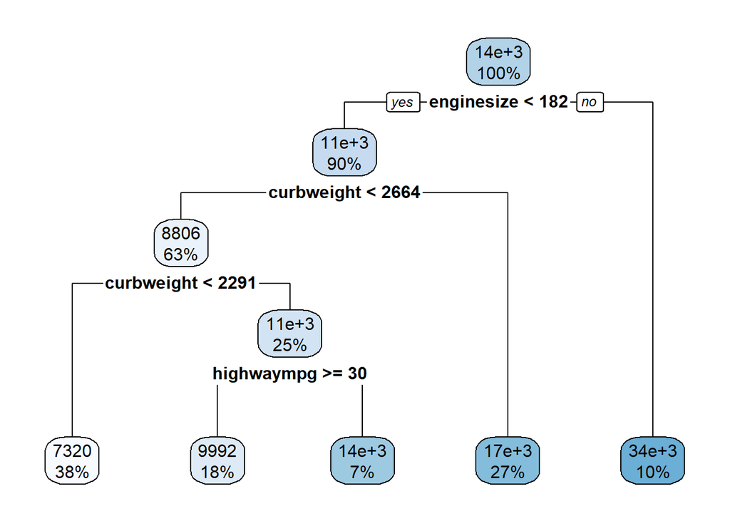

```r
rpart.plot(modelo_ar)
```

#### 3.3.2.3 Predicciones del modelo (ar)

```r
predicciones_ar <- predict(object = modelo_ar, newdata = datos.validacion)
predicciones_ar
```

```
##         9        10        33        44        47        56        57        72
## 16653.455 16653.455  7319.714 13739.250 16653.455 13739.250 13739.250 34278.324
##        77        84        87        89        97       100       104       107
##  7319.714 16653.455  9991.931  9991.931  7319.714  9991.931 16653.455 16653.455
##       108       116       122       132       138       140       142       147
## 16653.455 16653.455  7319.714  9991.931 16653.455  7319.714  7319.714  7319.714
##       148       149       155       156       160       161       167       171
##  9991.931 13739.250  7319.714 16653.455  7319.714  7319.714 13739.250 16653.455
##       173       178       188       192       196       201       203       204
## 16653.455  9991.931  9991.931 13739.250 16653.455 16653.455 16653.455 16653.455
```

#### 3.3.2.4 Tabla comparativa

```r
comparaciones <- data.frame(precio_real = datos.validacion$price,  precio_predicciones = predicciones_ar)
```

```r
kable(head(comparaciones, 10), caption = "Arbol de regresión. Comparación precios reales VS predicción de precios. 10 primeras predicciones") %>%
  kable_styling(full_width = F, bootstrap_options = c("striped", "bordered", "condensed")) %>%
 kable_paper("hover")
```

Arbol de regresión. Comparación precios reales VS predicción de precios. 10 primeras predicciones

|  | precio_real | precio_predicciones |
| --- | --- | --- |
| 9 | 23875.00 | 16653.455 |
| 10 | 17859.17 | 16653.455 |
| 33 | 5399.00 | 7319.714 |
| 44 | 6785.00 | 13739.250 |
| 47 | 11048.00 | 16653.455 |
| 56 | 10945.00 | 13739.250 |
| 57 | 11845.00 | 13739.250 |
| 72 | 34184.00 | 34278.324 |
| 77 | 5389.00 | 7319.714 |
| 84 | 14869.00 | 16653.455 |

#### 3.3.2.5 RMSE modelo de ar

```r
rmse_ar <- rmse(comparaciones$precio_real, comparaciones$precio_predicciones)
rmse_ar
```

```
## [1] 3217.158
```

### 3.3.3 Modelo de bosques aleatorios (RF)

```r
modelo_rf <- randomForest(x = datos.entrenamiento[,c("symboling", "wheelbase",
                                "carlength", "carwidth", "carheight", "curbweight",
                                "enginesize", "boreratio", "stroke",
                                "compressionratio", "horsepower", "peakrpm",
                                "citympg", "highwaympg" )],
                          y = datos.entrenamiento[,'price'],
                          importance = TRUE,
                          keep.forest = TRUE,
                          ntree=20)
modelo_rf
```

```
##
## Call:
##  randomForest(x = datos.entrenamiento[, c("symboling", "wheelbase",      "carlength", "carwidth", "carheight", "curbweight", "enginesize",      "boreratio", "stroke", "compressionratio", "horsepower",      "peakrpm", "citympg", "highwaympg")], y = datos.entrenamiento[,      "price"], ntree = 20, …
##                Type of random forest: regression
##                      Number of trees: 20
## No. of variables tried at each split: 4
##
##           Mean of squared residuals: 4447333
##                     % Var explained: 93.65
```

#### 3.3.3.1 Variables de importancia

```r
as.data.frame(modelo_rf$importance) %>%
    arrange(desc(IncNodePurity))
```

```
##                     %IncMSE IncNodePurity
## enginesize       49729573.3    4931905857
## highwaympg       13259713.3    1526465689
## curbweight       12701949.8     963951056
## horsepower        8623072.0     880190906
## carlength         3045830.6     737353416
## wheelbase         6255495.2     528155676
## citympg           3812712.5     370359547
## carwidth          2516471.0     311465860
## boreratio         4479711.1     257610626
## compressionratio  1017535.0     149039936
## peakrpm           1939356.6     127464095
## stroke            1493552.1      51783892
## carheight          659535.1      51572211
## symboling          274547.4      34059590
```

#### 3.3.3.2 Predicciones del modelo (rf)

```r
predicciones_rf <- predict(object = modelo_rf, newdata = datos.validacion)
predicciones_rf
```

```
##         9        10        33        44        47        56        57        72
## 19545.596 18617.807  6295.784 10161.188 13073.485 13817.543 13817.543 35946.032
##        77        84        87        89        97       100       104       107
##  5891.486 13470.944  8822.478  9607.702  6859.600  9450.738 14622.413 16847.024
##       108       116       122       132       138       140       142       147
## 15300.398 15279.498  7156.435  9794.326 15916.927  7990.458  7935.674  8767.958
##       148       149       155       156       160       161       167       171
##  9667.052 11505.499  7957.923 10298.215  8022.398  7122.327  9752.818 11191.824
##       173       178       188       192       196       201       203       204
## 11812.162  9909.652  8265.507 15973.523 15680.271 18622.537 18923.450 17244.725
```

#### 3.3.3.3 Tabla comparativa

```r
comparaciones <- data.frame(precio_real = datos.validacion$price,  precio_predicciones = predicciones_rf)
```

```r
kable(head(comparaciones, 10), caption = "Random Forest. Comparación precios reales VS predicción de precios. 10 primeras predicciones") %>%
  kable_styling(full_width = F, bootstrap_options = c("striped", "bordered", "condensed")) %>%
 kable_paper("hover")
```

Random Forest. Comparación precios reales VS predicción de precios. 10 primeras predicciones

|  | precio_real | precio_predicciones |
| --- | --- | --- |
| 9 | 23875.00 | 19545.596 |
| 10 | 17859.17 | 18617.807 |
| 33 | 5399.00 | 6295.784 |
| 44 | 6785.00 | 10161.188 |
| 47 | 11048.00 | 13073.485 |
| 56 | 10945.00 | 13817.542 |
| 57 | 11845.00 | 13817.542 |
| 72 | 34184.00 | 35946.032 |
| 77 | 5389.00 | 5891.486 |
| 84 | 14869.00 | 13470.944 |

```r
rmse_rf <- rmse(comparaciones$precio_real, comparaciones$precio_predicciones)
rmse_rf
```

```
## [1] 2146.428
```

## 3.4 Evaluación de modelos

Se comparan las predicciones

```r
comparaciones <- data.frame(cbind(datos.validacion[,-1], predicciones_rm, predicciones_ar, predicciones_rf))
```

Se visualizan las predicciones de cada modelo

```r
kable(comparaciones, caption = "Predicciones de los modelos") %>%
  kable_styling(full_width = F, bootstrap_options = c("striped", "bordered", "condensed")) %>%
 kable_paper("hover")
```

Predicciones de los modelos

|  | symboling | wheelbase | carlength | carwidth | carheight | curbweight | enginesize | boreratio | stroke | compressionratio | horsepower | peakrpm | citympg | highwaympg | price | predicciones_rm | predicciones_ar | predicciones_rf |
| --- | --- | --- | --- | --- | --- | --- | --- | --- | --- | --- | --- | --- | --- | --- | --- | --- | --- | --- |
| 9 | 1 | 105.8 | 192.7 | 71.4 | 55.9 | 3086 | 131 | 3.13 | 3.400 | 8.3 | 140 | 5500 | 17 | 20 | 23875.00 | 16942.803 | 16653.455 | 19545.596 |
| 10 | 0 | 99.5 | 178.2 | 67.9 | 52.0 | 3053 | 131 | 3.13 | 3.400 | 7.0 | 160 | 5500 | 16 | 22 | 17859.17 | 16473.778 | 16653.455 | 18617.807 |
| 33 | 1 | 93.7 | 150.0 | 64.0 | 52.6 | 1837 | 79 | 2.91 | 3.070 | 10.1 | 60 | 5500 | 38 | 42 | 5399.00 | 5301.044 | 7319.714 | 6295.784 |
| 44 | 0 | 94.3 | 170.7 | 61.8 | 53.5 | 2337 | 111 | 3.31 | 3.230 | 8.5 | 78 | 4800 | 24 | 29 | 6785.00 | 7204.223 | 13739.250 | 10161.188 |
| 47 | 2 | 96.0 | 172.6 | 65.2 | 51.4 | 2734 | 119 | 3.43 | 3.230 | 9.2 | 90 | 5000 | 24 | 29 | 11048.00 | 11022.515 | 16653.455 | 13073.485 |
| 56 | 3 | 95.3 | 169.0 | 65.7 | 49.6 | 2380 | 70 | 3.33 | 3.255 | 9.4 | 101 | 6000 | 17 | 23 | 10945.00 | 7851.656 | 13739.250 | 13817.542 |
| 57 | 3 | 95.3 | 169.0 | 65.7 | 49.6 | 2380 | 70 | 3.33 | 3.255 | 9.4 | 101 | 6000 | 17 | 23 | 11845.00 | 7851.656 | 13739.250 | 13817.542 |
| 72 | -1 | 115.6 | 202.6 | 71.7 | 56.5 | 3740 | 234 | 3.46 | 3.100 | 8.3 | 155 | 4750 | 16 | 18 | 34184.00 | 31588.516 | 34278.324 | 35946.032 |
| 77 | 2 | 93.7 | 157.3 | 64.4 | 50.8 | 1918 | 92 | 2.97 | 3.230 | 9.4 | 68 | 5500 | 37 | 41 | 5389.00 | 5979.030 | 7319.714 | 5891.486 |
| 84 | 3 | 95.9 | 173.2 | 66.3 | 50.2 | 2921 | 156 | 3.59 | 3.860 | 7.0 | 145 | 5000 | 19 | 24 | 14869.00 | 15252.727 | 16653.455 | 13470.944 |
| 87 | 1 | 96.3 | 172.4 | 65.4 | 51.6 | 2405 | 122 | 3.35 | 3.460 | 8.5 | 88 | 5000 | 25 | 32 | 8189.00 | 10378.638 | 9991.931 | 8822.478 |
| 89 | -1 | 96.3 | 172.4 | 65.4 | 51.6 | 2403 | 110 | 3.17 | 3.460 | 7.5 | 116 | 5500 | 23 | 30 | 9279.00 | 10405.155 | 9991.931 | 9607.702 |
| 97 | 1 | 94.5 | 165.3 | 63.8 | 54.5 | 1971 | 97 | 3.15 | 3.290 | 9.4 | 69 | 5200 | 31 | 37 | 7499.00 | 6684.602 | 7319.714 | 6859.600 |
| 100 | 0 | 97.2 | 173.4 | 65.2 | 54.7 | 2324 | 120 | 3.33 | 3.470 | 8.5 | 97 | 5200 | 27 | 34 | 8949.00 | 10903.360 | 9991.931 | 9450.738 |
| 104 | 0 | 100.4 | 184.6 | 66.5 | 55.1 | 3060 | 181 | 3.43 | 3.270 | 9.0 | 152 | 5200 | 19 | 25 | 13499.00 | 22703.983 | 16653.455 | 14622.413 |
| 107 | 1 | 99.2 | 178.5 | 67.9 | 49.7 | 3139 | 181 | 3.43 | 3.270 | 9.0 | 160 | 5200 | 19 | 25 | 18399.00 | 23008.175 | 16653.455 | 16847.024 |
| 108 | 0 | 107.9 | 186.7 | 68.4 | 56.7 | 3020 | 120 | 3.46 | 3.190 | 8.4 | 97 | 5000 | 19 | 24 | 11900.00 | 14327.392 | 16653.455 | 15300.398 |
| 116 | 0 | 107.9 | 186.7 | 68.4 | 56.7 | 3075 | 120 | 3.46 | 3.190 | 8.4 | 97 | 5000 | 19 | 24 | 16630.00 | 14428.427 | 16653.455 | 15279.498 |
| 122 | 1 | 93.7 | 167.3 | 63.8 | 50.8 | 1989 | 90 | 2.97 | 3.230 | 9.4 | 68 | 5500 | 31 | 38 | 6692.00 | 6166.339 | 7319.714 | 7156.435 |
| 132 | 2 | 96.1 | 176.8 | 66.6 | 50.5 | 2460 | 132 | 3.46 | 3.900 | 8.7 | 90 | 5100 | 23 | 31 | 9895.00 | 11091.658 | 9991.931 | 9794.326 |
| 138 | 2 | 99.1 | 186.6 | 66.5 | 56.1 | 2847 | 121 | 3.54 | 3.070 | 9.0 | 160 | 5500 | 19 | 26 | 18620.00 | 16276.811 | 16653.455 | 15916.927 |
| 140 | 2 | 93.7 | 157.9 | 63.6 | 53.7 | 2120 | 108 | 3.62 | 2.640 | 8.7 | 73 | 4400 | 26 | 31 | 7053.00 | 8985.576 | 7319.714 | 7990.458 |
| 142 | 0 | 97.2 | 172.0 | 65.4 | 52.5 | 2145 | 108 | 3.62 | 2.640 | 9.5 | 82 | 4800 | 32 | 37 | 7126.00 | 9585.263 | 7319.714 | 7935.674 |
| 147 | 0 | 97.0 | 173.5 | 65.4 | 53.0 | 2290 | 108 | 3.62 | 2.640 | 9.0 | 82 | 4800 | 28 | 32 | 7463.00 | 9661.038 | 7319.714 | 8767.958 |
| 148 | 0 | 97.0 | 173.5 | 65.4 | 53.0 | 2455 | 108 | 3.62 | 2.640 | 9.0 | 94 | 5200 | 25 | 31 | 10198.00 | 12213.061 | 9991.931 | 9667.052 |
| 149 | 0 | 96.9 | 173.6 | 65.4 | 54.9 | 2420 | 108 | 3.62 | 2.640 | 9.0 | 82 | 4800 | 23 | 29 | 8013.00 | 11235.252 | 13739.250 | 11505.499 |
| 155 | 0 | 95.7 | 169.7 | 63.6 | 59.1 | 2290 | 92 | 3.05 | 3.030 | 9.0 | 62 | 4800 | 27 | 32 | 7898.00 | 6490.468 | 7319.714 | 7957.922 |
| 156 | 0 | 95.7 | 169.7 | 63.6 | 59.1 | 3110 | 92 | 3.05 | 3.030 | 9.0 | 62 | 4800 | 27 | 32 | 8778.00 | 7996.805 | 16653.455 | 10298.215 |
| 160 | 0 | 95.7 | 166.3 | 64.4 | 52.8 | 2275 | 110 | 3.27 | 3.350 | 22.5 | 56 | 4500 | 38 | 47 | 7788.00 | 10685.304 | 7319.714 | 8022.398 |
| 161 | 0 | 95.7 | 166.3 | 64.4 | 53.0 | 2094 | 98 | 3.19 | 3.030 | 9.0 | 70 | 4800 | 38 | 47 | 7738.00 | 7017.584 | 7319.714 | 7122.328 |
| 167 | 1 | 94.5 | 168.7 | 64.0 | 52.6 | 2300 | 98 | 3.24 | 3.080 | 9.4 | 112 | 6600 | 26 | 29 | 9538.00 | 11959.446 | 13739.250 | 9752.818 |
| 171 | 2 | 98.4 | 176.2 | 65.6 | 52.0 | 2679 | 146 | 3.62 | 3.500 | 9.3 | 116 | 4800 | 24 | 30 | 11199.00 | 14219.038 | 16653.455 | 11191.824 |
| 173 | 2 | 98.4 | 176.2 | 65.6 | 53.0 | 2975 | 146 | 3.62 | 3.500 | 9.3 | 116 | 4800 | 24 | 30 | 17669.00 | 14925.579 | 16653.455 | 11812.162 |
| 178 | -1 | 102.4 | 175.6 | 66.5 | 53.9 | 2458 | 122 | 3.31 | 3.540 | 8.7 | 92 | 4200 | 27 | 32 | 11248.00 | 8406.054 | 9991.931 | 9909.652 |
| 188 | 2 | 97.3 | 171.7 | 65.5 | 55.7 | 2319 | 97 | 3.01 | 3.400 | 23.0 | 68 | 4500 | 37 | 42 | 9495.00 | 8669.066 | 9991.931 | 8265.507 |
| 192 | 0 | 100.4 | 180.2 | 66.9 | 55.1 | 2661 | 136 | 3.19 | 3.400 | 8.5 | 110 | 5500 | 19 | 24 | 13295.00 | 15473.126 | 13739.250 | 15973.522 |
| 196 | -1 | 104.3 | 188.8 | 67.2 | 57.5 | 3034 | 141 | 3.78 | 3.150 | 9.5 | 114 | 5400 | 23 | 28 | 13415.00 | 17905.580 | 16653.455 | 15680.271 |
| 201 | -1 | 109.1 | 188.8 | 68.9 | 55.5 | 2952 | 141 | 3.78 | 3.150 | 9.5 | 114 | 5400 | 23 | 28 | 16845.00 | 18628.974 | 16653.455 | 18622.537 |
| 203 | -1 | 109.1 | 188.8 | 68.9 | 55.5 | 3012 | 173 | 3.58 | 2.870 | 8.8 | 134 | 5500 | 18 | 23 | 21485.00 | 24791.956 | 16653.455 | 18923.450 |
| 204 | -1 | 109.1 | 188.8 | 68.9 | 55.5 | 3217 | 145 | 3.01 | 3.400 | 23.0 | 106 | 4800 | 26 | 27 | 22470.00 | 19036.351 | 16653.455 | 17244.725 |

Se compara el RMSE

```r
rmse <- data.frame(rm = rmse_rm, ar = rmse_ar, rf = rmse_rf)
```

```r
kable(rmse, caption = "Estadístico RMSE de cada modelo") %>%
  kable_styling(full_width = F, bootstrap_options = c("striped", "bordered", "condensed")) %>%
 kable_paper("hover")
```

Estadístico RMSE de cada modelo

| rm | ar | rf |
| --- | --- | --- |
| 2915.551 | 3217.158 | 2146.428 |

# 4 Interpretación

Se cargaron datos numéricos de precios de automóviles basados en algunas variables numéricas.

El modelo de regresión linea múltiple destaca variables estadísticamente significativas: - enginesize -> 99.9999 % - stroke -> 99.9829 % - peakrpm -> 99.9676 % - compressionratio -> 99.5797 % - citympg -> 94.2072 % - highwaympg -> 90.0782 %

El mejor modelo conforme al estadístico raiz del error cuadrático medio (*rmse*) fue el de bosques aleatorios con estos datos de entrenamiento y validación y con el porcentaje de datos de entrenamiento y validación de 80% y 20%. Asi quedaron de mas aceptado al menor:

1. Random Forest 2146.428
2. Regresión Multiple 2915.551
3. Arbol de Regresión 3217.158